# Profiting from Sustainability: A Look into Environmentally Conscious Companies

Alex Ristic, Molly Cooper

11-10-2020

# An Introduction to Sustainability

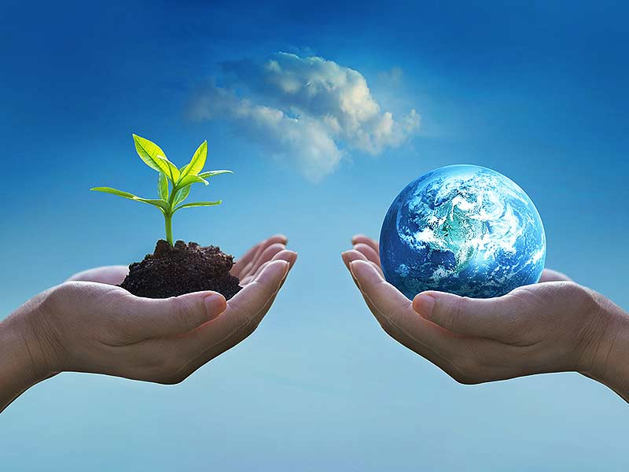

## Planet, People, Profits

In the context of individual and corporate practices, *Sustainability* refers to making decisions that have a positive long-term impact on global and local environments. More specifically, sustainable companies are those that achieve their current goals without jeopardizing the way of life of future generations. The concept of sustainability and ‘sustainable practices’ is broken up into three areas, or pillars:

**1. Environmental (Planet)**

Decisions and processes that protect the environment. This includes reducing waste production, water usage, and carbon footprints.

**2. Social (People)**

Having a positive impact on employees and human well-being: workers’ rights, company benefits (insurance, paid leave), resources (education, training), avoiding child labor, fundraising and community outreach efforts, investing in public projects.

**3. Economic (Profits)**

Refers to the importance of profits: a sustainable company must also be profitable to ensure that its efforts are not short-lived. Also refers to government subsidies and legislation that may encourage sustainable business practices.

These pillars are often used to evaluate the overall sustainability of a company’s practices, plans, and strategies.

Examples of sustainable efforts:

- General Motors, Volkswagen, and BMW, and other car manufacturers introducing electric vehicles
- Nike and Adidas reducing water, paper, and energy usage. Both brands have introduced shoes made out of recycled materials.
- Patagonia using recycled cans and bottles to make the polyester for many of its clothing items
- The United Kingdom subsidizing battery production for electric vehicles

[figure not shown]

Adidas x Parley for the Oceans

## Why it Matters

So, why should businesses care about sustainability? For one, there in a moral and ethical responsibility surrounding how we (both individuals and corporations) make decisions and achieve our goals, as these decisions have a direct impact on present and future communities. Moreover, corporate strategy is able to have a very significant impact, both positive and negative, on global health and future environmental outcomes. For example, the 1.6 million kilometer mass of plastic floating in the Pacific Ocean can be attributed to companies using cheap plastic materials to manufacture and package their products. Additionally, CO2 emissions from manufacturing and traditional energy plants contribute to increases in the earth’s temperature, which is projected to cause rising sea levels and destructive natural disasters.

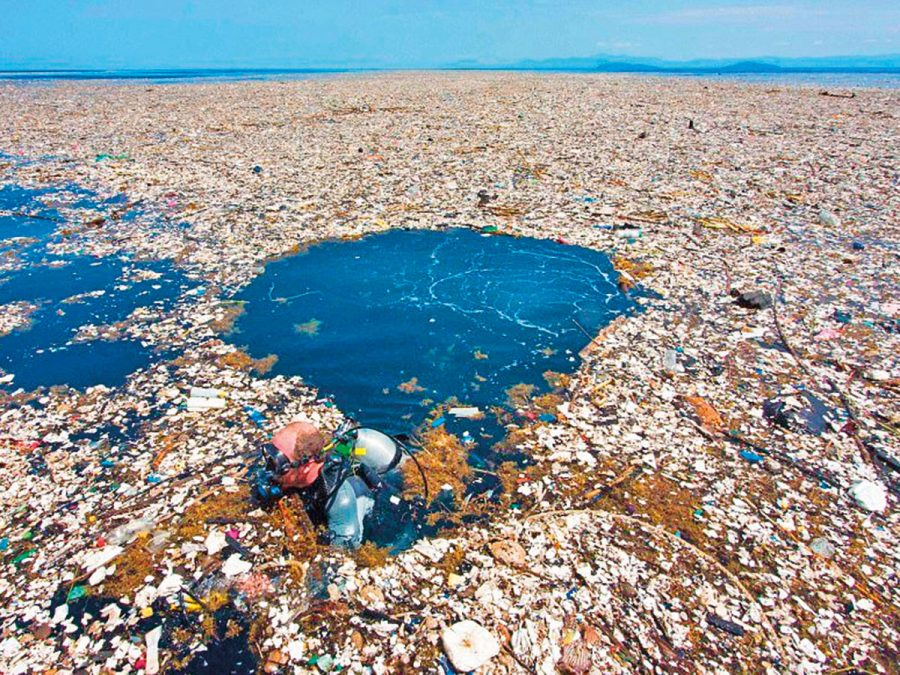

Pacific Ocean Garbage Gyre

Sustainability efforts also have monetary motivations. Many CEOs, consumer researchers, and businesses analysts have found that sustainable business practices may be crucial for maintaining market share and revenue growth.

Consumers tend to make purchases that align with their beliefs and values, and these values often involve climate change and positive impacts on the environment. A survey from Cone Communications found that **87%** of American consumers will purchase something from a company if it advocated for an issue that they care about, and that **63%** of Americans want corporations to drive social and environmental change.

Moreover, sustainable goods are projected to be growing market. A 2018 report from Nielsen Global Media found that **$128.5 billion** was spent on sustainable goods and products in 2018 and estimated that this number will reach **$150 billion by 2021.** Nielsen attributes much of this growth to Millenial consumers, who are more likely to change their shopping habits and are willing to pay more for products that are environmentally ‘friendly.’ As Millenials gradually make a larger and larger proportion of the consumer market, sustainability will become more and more of a necessity for companies that want to maintain market share and brand loyalty.

## Our Question

With the increasing importance of sustainability on a company’s reputation, marketing strategies, and market share, we aim to investigate and quantify the impacts that sustainability efforts have on a company’s growth and economic success, as well as the prevalence of sustainable companies throughout the U.S. and throughout the world. An understanding of how sustainable strategies affect corporate growth and profits throughout different industries and sectors can be useful information for investors, entrepreneurs, and current business leaders who wish to take advantage of sustainability’s continuing growth and relevance in the corporate sphere.

# Sustainability in U.S. Companies

## Our Data: ESG Scores and Fortune 100 Companies

### Environmental, Social, and Governance (ESG)

*ESG* refers to a set of criteria that investors, fund managers, and research analysts use to evaluate a company’s practices and strategies from three different perspectives: environmental impact, relationship with communities and employees, and financial and managerial ethics (shareholders’ rights, insider trading). Investors and professional asset managers use ESG research and systems of ESG ‘ratings’ to screen for ESG investing opportunities — both for themselves and for clients.

Public (ie. free) ESG data is typically very hard to come by, as it’s often used by professional and retail investors to help make profitable investment decisions. As a result, ESG research companies, like [Sustainalytics](https://www.sustainalytics.com/esg-ratings/) generally charge a (several hundred dollar) subscription fee to gain access to their large sets of ESG data and research reports. However, Sustainalytics does have a free ESG Rating search tool that returns ESG Risk Ratings for any publicly-traded company.

[figure not shown]

Sustainalytics ESG Report for Exxon Mobil

To collect these ESG scores, we used a web-scraping bot that utilizes Selenium software. The bot enters the desired company name into the ESG tool’s search bar and then scrapes the corresponding ESG Risk Rating. This provided us with a method to collect ESG scores for a collection of companies of our choosing.

### Top 75 U.S. Companies

We pulled revenue, revenue growth, industry name, and headquarters data for the largest revenue generating companies in the U.S., with the exception of 13 companies which are not publicly traded (and thus did not have ESG scores available). We chose to investigate top-revenue-earning companies because they are (arguably) the most successful companies in the U.S. and therefore likely have the most influence and presence among U.S. corporate activity. Furthermore, these companies make up many factions of American life from E-Commerce to Oil to Food and Beverages. These companies have far reaching economic, social, and environmental implications, thus it’s essential to consider their efforts to combat climate change, foster equality, and impart positive changes, not only in America, but globally.

Once we had our dataset of U.S. companies, we passed each of their names into the Selenium bot to their respective ESG Risk Ratings.

### ESG Across U.S. Sectors

To address our first question — How does Sustainability vary among industries and sectors? — we assigned each of the top-75 companies to one of five sector ‘groups.’ The sector group assignments followed the criteria below:

```r
# group similar sectors together for stat analyses
esg_grouped <- esg %>%
  mutate(sector_group = case_when(
    sector == 'Communication Services' |
      sector == 'Telecommunications' |
      sector == 'Technology' ~ "Tech, Telecomm, and Communications",
    sector == 'Consumer Discretionary' |
      sector == 'Consumer Staples' ~ 'Consumer Disc. and Staples',
    sector == 'Financials' ~ 'Financials',
    sector == 'Energy' |
      sector == 'Materials' |
      sector == 'Industrials' ~ 'Energy, Materials, and Industrials',
    sector == 'Health Care' ~ 'Health Care'))
```

Sectors were grouped together if their respective companies carried out similar functions or provided similar goods/services. This was done because, originally, we had some individual sectors (such as Materials) that had very few observations, and this would have prevented us from moving forward with any statistical analyses.

To start, we compared the medians and spreads of ESG Risk Ratings among our five sector groups using a box plot. The plot and table below reveal that the Energy, Materials, and Industrials group has the highest mean and median risk rating, while the Tech, Telecomm, and Communications group has the lowest mean and median rating.

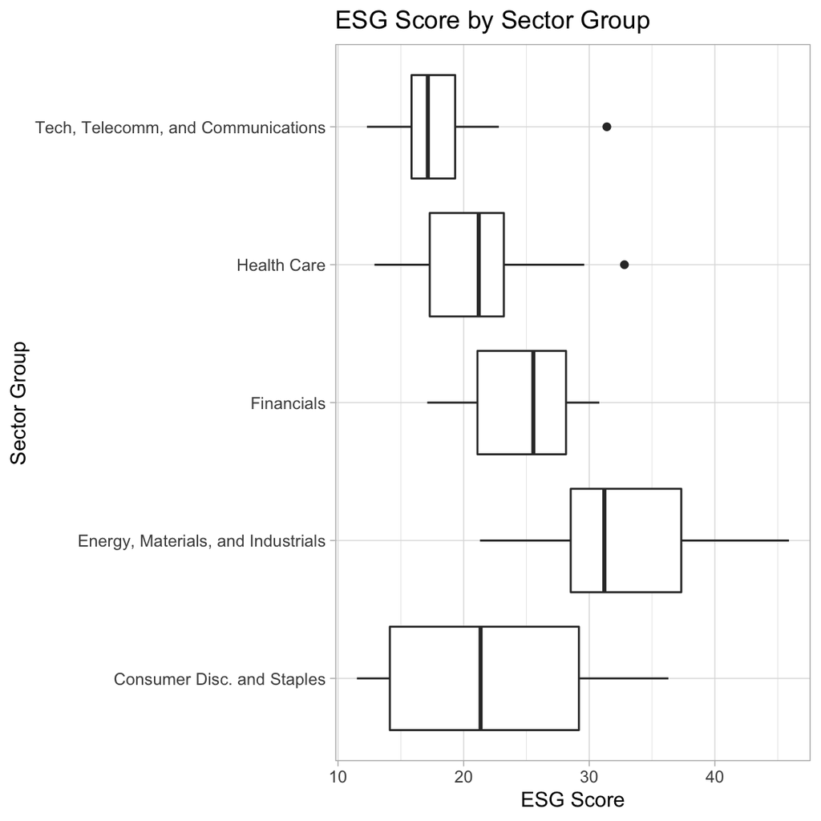

ESG Score by Sector Group

| Sector Group | Mean Score | Median Score | Std. Deviation |
| --- | --- | --- | --- |
| Energy, Materials, and Industrials | 32.1688 | 31.20 | 6.9871 |
| Financials | 24.6929 | 25.55 | 4.5198 |
| Consumer Disc. and Staples | 21.9062 | 21.35 | 8.4521 |
| Health Care | 21.4385 | 21.20 | 5.9197 |
| Tech, Telecomm, and Communications | 18.0571 | 17.15 | 4.7683 |

For our next question — whether Sustainability efforts have an impact on corporate revenues — we conducted a linear regression with ESG Risk Rating as a predictor variable and revenue growth as the response variable. When checking linearity and normality assumptions, we found that the relationship between revenue growth and esg rating is not very linear, regardless if log or square root transformations are applied. Similarly, we found that applying log and square root transformations did not resolve the lack of normality in our predictor and response variables; the log transformation appeared to improve normality in for revenue growth in some sector groups, but we reasoned that this improvement was marginal, and ultimately decided to proceed with the original, untransformed data. We recognize that these assumptions — normality and linearity — are not fully met and recognize the limitations of our results going forward.

### Transformations

#### No Transformations

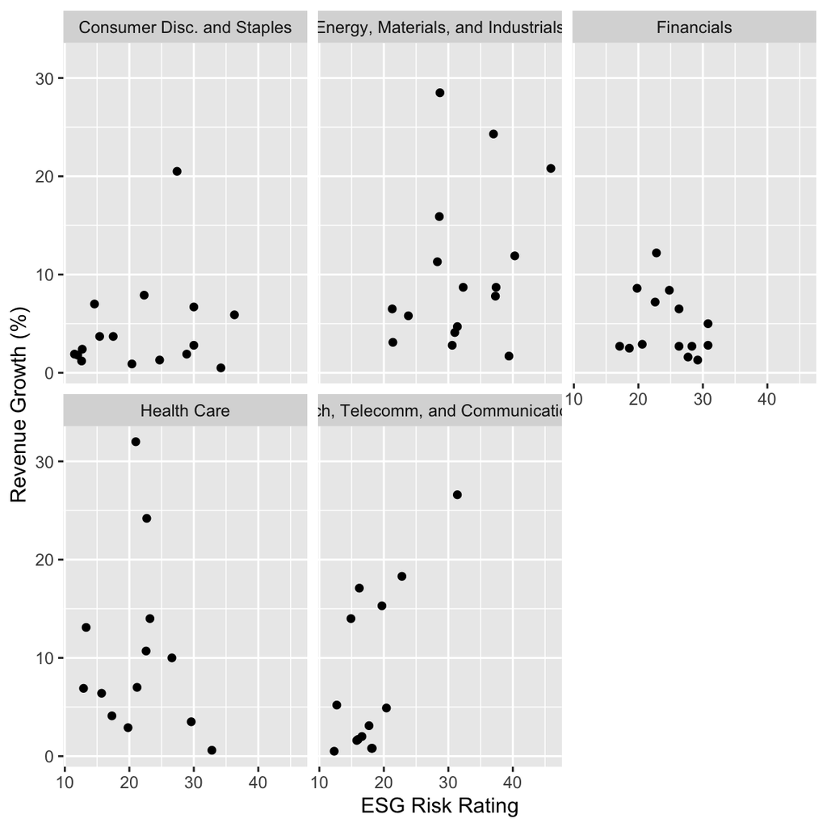

#### Log Transformations

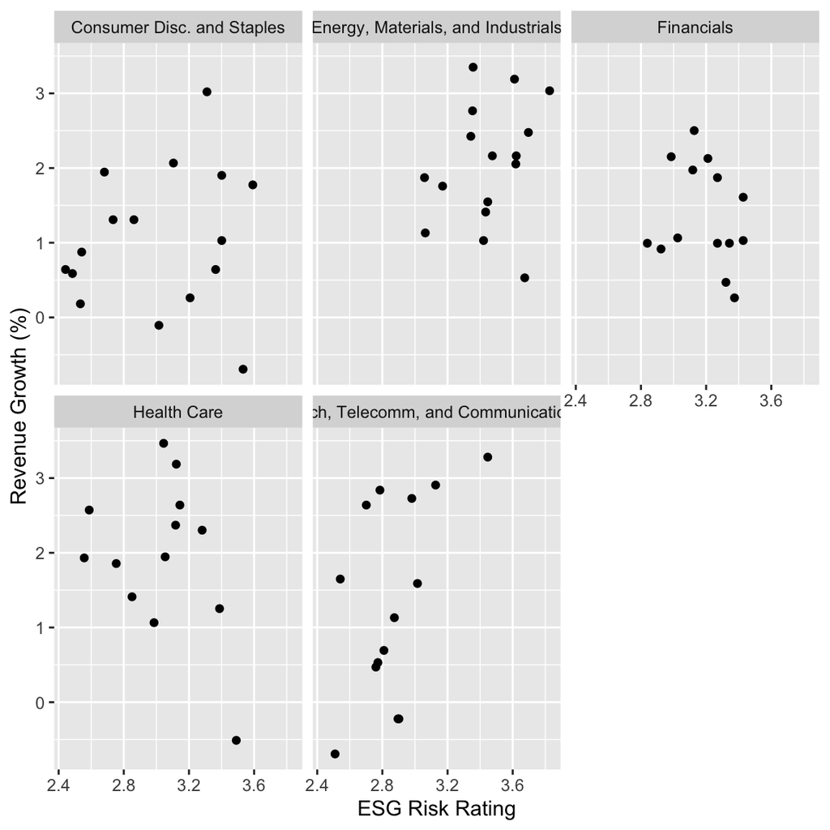

#### Square Root Transformations

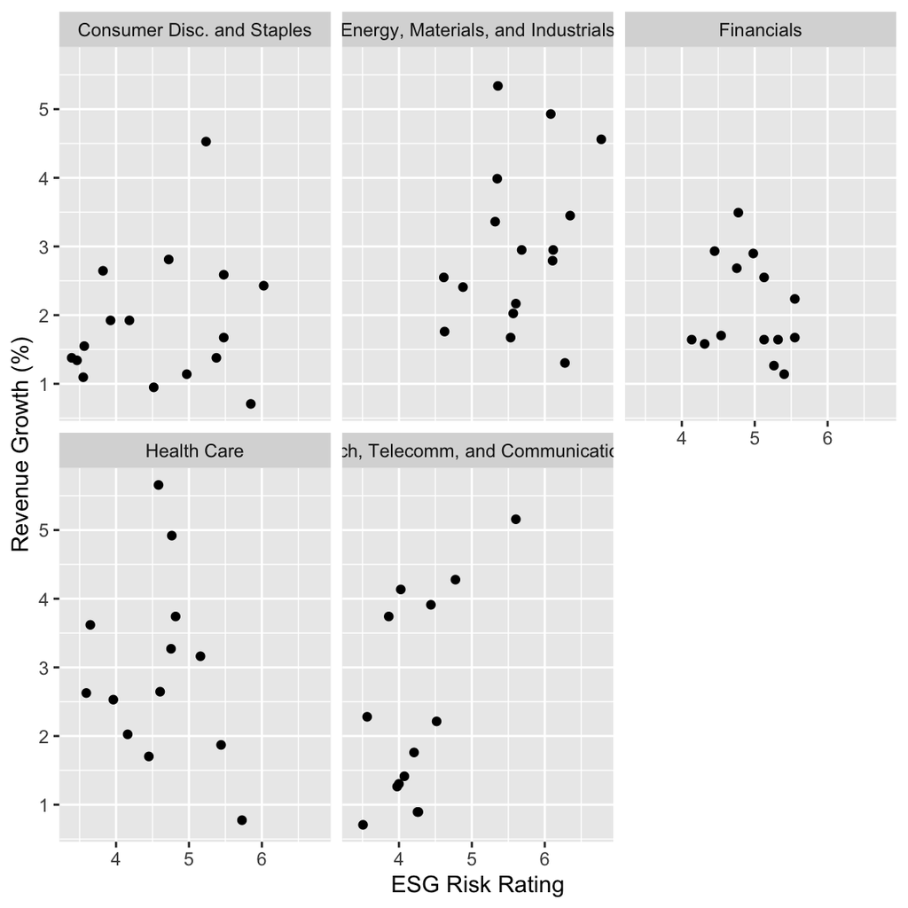

### Impact on Revenue Growth

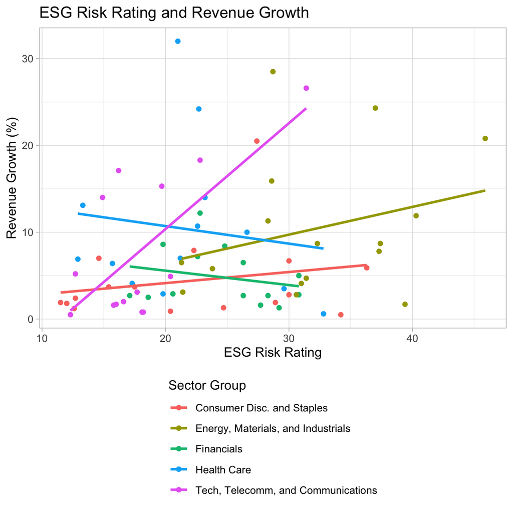

Linear Regression: ESG Risk Rating Predicting Revenue Growth (Revenue Growth ~ ESG)

| X1 | Sector Group | Coeff. Estimate | p-value |
| --- | --- | --- | --- |
| 1 | Consumer Disc. and Staples | 0.1277 | 0.5337 |
| 2 | Energy, Materials, and Industrials | 0.3196 | 0.2002 |
| 3 | Tech, Telecomm, and Communications | 1.2202 | 0.0026 |
| 4 | Health Care | -0.2023 | 0.5369 |
| 5 | Financials | -0.1661 | 0.6867 |
| 6 | All Groups | 0.2049 | 0.0603 |

Our regressions on each sector group yielded positive estimates for the ESG coefficient for three groups and negative estimates for two groups; however, only the estimate for *Tech, Telecomm, adn Communications* was found to be significant at the 0.05 confidence level. This was fairly expected since we had a relatively small number of observations within each sector group, as well difficulty meeting the linearity and normality assumptions. An aggregate/ungrouped regression on all of the companies yielded a positive coefficient estimate and was significant at the 0.10 confidence level.

An interesting result is that our significant coefficient estimate for Tech, Telecomm, and Communications was positive. Indeed, even though most of our estimates were insignificant at the 0.05 level, the majority of them were positive, rather than negative. This seems to contradict the literature that sustainability efforts are a driver of market share and sales growth. However, the companies in our dataset are top-earners and are therefore not very representative of the average corporation in the U.S. With this and our assumption violations in mind, we recognize that these results may not be indicative of a negative association between sustainability efforts and prospective revenue growth.

To address our last question regarding the location of sustainable companies in the U.S., we constructed a choropleth map colored by average ESG Risk Rating. That is, the color of each state on the map below reflects the average ESG Risk Rating of all the top-75 companies that are headquartered in that state.

### ESG in the U.S.

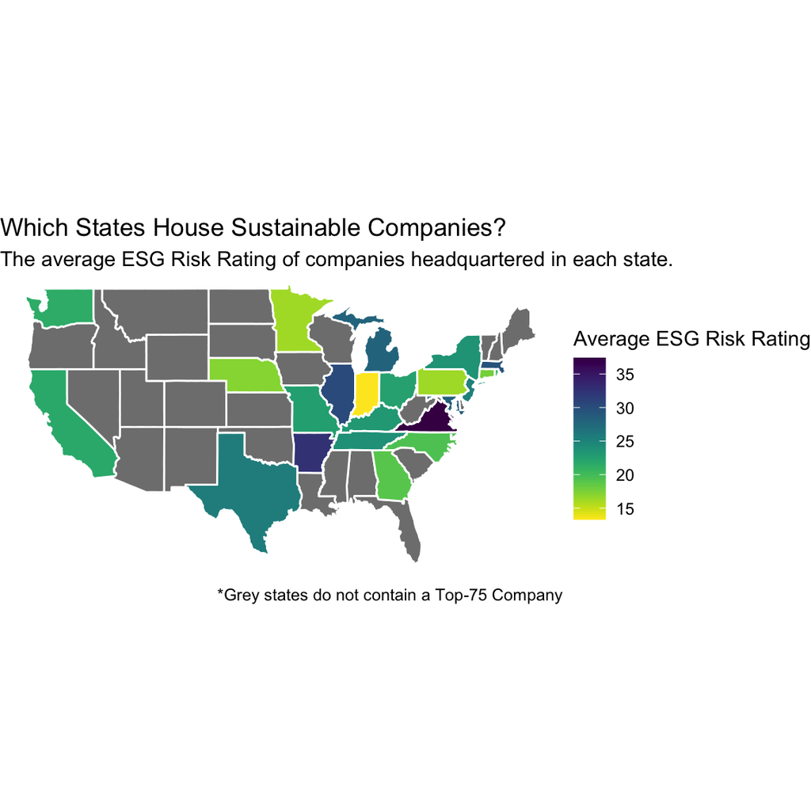

#### Highest Risk States

States with Highest Average ESG Risk

| State | Average Company ESG Risk Rating |
| --- | --- |
| Virginia | 37.40 |
| Arkansas | 32.60 |
| Illinois | 30.35 |

Companies in High Risk States

| Name | State | ESG Risk Rating | Sector Group |
| --- | --- | --- | --- |
| Caterpillar | Illinois | 39.4 | Energy, Materials, and Industrials |
| General Dynamics | Virginia | 37.4 | Energy, Materials, and Industrials |
| Boeing | Illinois | 37.0 | Energy, Materials, and Industrials |

#### Lowest Risk States

States with Lowest Average ESG Risk

| State | Average Company ESG Risk Rating |
| --- | --- |
| Indiana | 13.3 |
| Minnesota | 16.2 |
| Pennsylvania | 16.3 |

Companies in Low Risk States

| Name | State | ESG Risk Rating | Sector Group |
| --- | --- | --- | --- |
| Best Buy | Minnesota | 12.0 | Consumer Disc. and Staples |
| AmerisourceBergen | Pennsylvania | 12.9 | Health Care |
| Anthem | Indiana | 13.3 | Health Care |

# Global Sustainability

## Global Knights 100 Data

Our Global Sustainability data set comes from the annual Global Knights 100 2020, which measures public companies throughout the globe with over $1 Billion in revenue annually based on their resource, employee, and financial management. These companies represent the top scoring in all of these categories throughout the World. The data is publicly available each year and thus we simply scraped the page from the website. We then used this information to plot the location of the top 100 companies which have great impact and are taking great strides in sustainability practices, financial allotment, and employee treatment throughout the globe.

## Most Sustainable Companies in the World

[interactive chart not shown]

# Conclusion

To summarize our findings we saw that within US companies, the Energy, Materials, and Industrial sectors displayed the highest overall ESG Risk Ratings We then saw that Technology, Telecommunications, and Media had the lowest average ESG Risk Ratings Worldwide, we can see a heavy concentration of the most sustainable companies in the US and Europe.

We faced large limitations in the scope of data available to report for our project. This was mainly due to the amount of free and publicly available information on companies in the US and Globally. Our choices of top-revenue companies was limited, as over 10 of the companies in the top-100 are not publicly traded and thus did not have ESG scores to report. Subsequently, we were limited to exploring sustainability within large companies because most smaller and mid-sized companies do not have publicly available data regarding sustainability metrics or revenue. However, with respect to the scope of our project this was not too problematic since we really wanted to look at how the largest companies with the most environmental, social, and economic impact handle sustainability and other metrics.

Thus, we limited the scope of our project, which has made it’s applicability a bit more narrow. If we were able to access a broader scope of data for private and smaller sized companies our US company metrics would have been more indicative of the state of sustainability and responsibility for the country as a whole. Many of the smaller companies have less resources and thus face more challenges in implementing environmental and social practices which are often costly and time-intensive. Our data is certainly skewed in that it represents companies with incredibly vast resources and abilities to implement whatever changes they see fit. We also could have looked more comprehensively at sustainability on a global scale if we had access to more information and there was a standardized metric by which companies are measured in regard to sustainability and social responsibility. ESG scores are currently the most standardized and publicly available numbers we have, but it certainly presents many limitations in access and companies which subscribe to these ratings.

Overall, we were still able to access ample data with regards to the most influential players in the US and many globally, thus our data and visuals were able to reveal a lot of important notions about the state of sustainability and social responsibility in the world.

## What’s Next?

With global climate change looming and cities becoming increasingly polluted and environmentally troubled, companies must use their resources and power to combat the crisis as best they can. Changing political tides within the US will likely have some influence on the effort and regulations regarding sustainable and ethical practices in business and many countries throughout the world have already begun to implement stricter regulations and encouraged better practices. The difficulty of accessing data regarding sustainability raises an alarming question of the ability for the public to hold companies accountable for their actions and encourage change when necessary. Thus, it’s imperative the more standardized metrics are established and public reporting becomes mandatory, otherwise it’s impossible for the public to understand and acknowledge the great positive and detrimental impacts many companies are causing to the world. Unsurprisingly, the global data revealed the traditionally wealthier and more developed countries house the most environmentally conscious companies which likely indicates the money and power required to implement better practices. This raises the concern that improving business practices is inaccessible for many and we must find a way to encourage and orchestrate economically feasible solutions to ineffective processes. As a society, we are moving in the right direction by generally recognizing institutional problems regarding social and environmental responsibility in business, but we must have more access and widely availible resources to truly move forward and impact the world in a powerful way.

### Sources

#### Background

https://www.imd.org/research-knowledge/articles/why-all-businesses-should-embrace-sustainability/ https://online.maryville.edu/blog/importance-of-environmental-awareness-when-running-a-business/ https://www.businessinsider.com/companies-using-recycled-plastic-in-products https://www.bizjournals.com/bizwomen/news/latest-news/2018/12/millennials-drive-big-growth-in-sustainable.html?page=all https://www.investopedia.com/terms/s/sustainability.asp https://www.investopedia.com/articles/investing/100515/three-pillars-corporate-sustainability https://www.investopedia.com/terms/e/environmental-social-and-governance-esg-criteria.asp

#### Images

https://www.lifealth.com/wellness/healthy-living/world-environment-day-2018-easy-ways-take-care-environment-av/77189/ https://www.businessinsider.com/companies-using-recycled-plastic-in-products https://chiletoday.cl/floating-garbage-patches-grow-in-the-pacific-ocean/

#### ESG Ratings

https://www.sustainalytics.com/esg-ratings/